# Exploratory Analysis

### Introduction

Some say climate change is the biggest threat of our age while others say it’s a myth based on dodgy science. These data sets, collected by Berkeley Earth, have data started in 1750 for average land temperature and 1850 for max and min land temperatures and global ocean and land temperatures. This report will illustrate the temperature change on the global level by showing three charts and one table.

### Summary

```
## $num_observations
## [1] 3192
##
## $max_land_temp
## [1] 21.32
##
## $min_land_temp
## [1] -5.407
##
## $average_land_temp
## [1] 8.374731
##
## $average_land_ocean_temp
## [1] 15.21257
```

There are 3192 numbers of data for the average land temperature, average max/min land temperature and average land and ocean temperature, collected each month starting at 1750 for land and 1850 for land and ocean. The average maximum land temperature is 21.32 Celsius and the average minimum land temperature is -5.41 Celsius. The average land temperature is 8.37 Celsius and the average land and ocean temperature is 15.21 Celsius

There are 3192 numbers of data for the average land temperature, average max/min land temperature and average land and ocean temperature, collected each month starting at 1750 for land and 1850 for land and ocean. The average maximum land temperature is 21.32 Celsius and the average minimum land temperature is -5.41 Celsius. The average land temperature is 8.37 Celsius and the average land and ocean temperature is 15.21 Celsius.

### Aggregated Table

| year | average |
| --- | --- |
| 2006 | 9.532500 |
| 2007 | 9.732167 |
| 2008 | 9.431750 |
| 2009 | 9.505250 |
| 2010 | 9.703083 |
| 2011 | 9.516000 |
| 2012 | 9.507333 |
| 2013 | 9.606500 |
| 2014 | 9.570667 |
| 2015 | 9.831000 |

This table includes the Average Land Temperature of the latest 10 years, from 2006 to 2015, in the dataset. The table is important as it shows the wavelike rise in average land temperature yearly.

### Chart 1

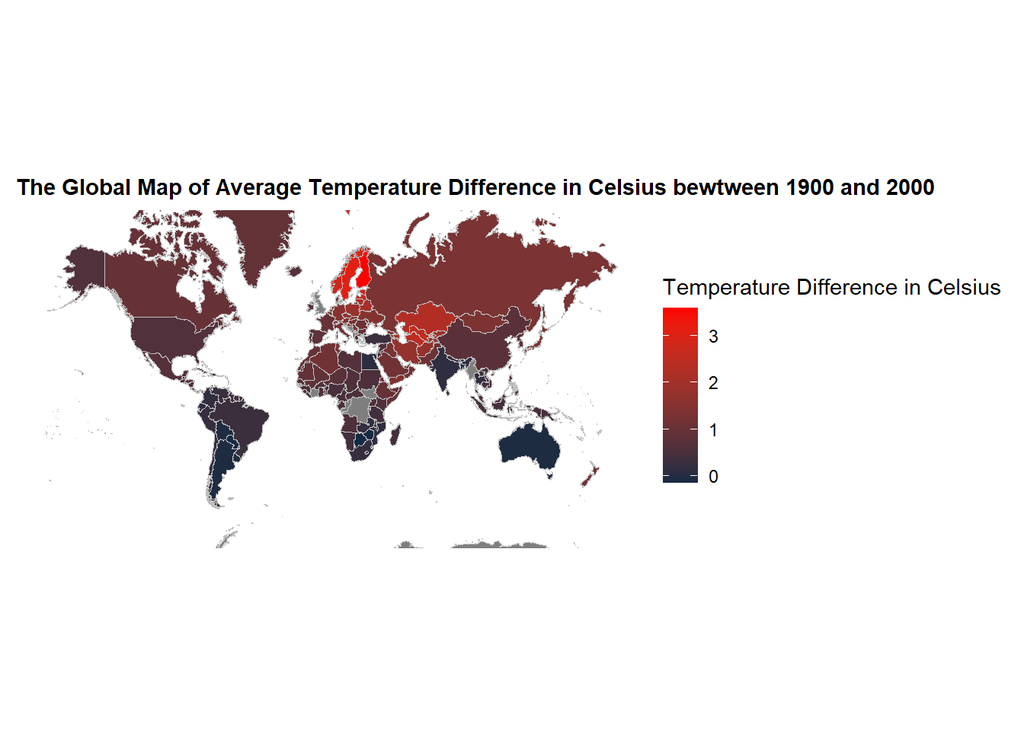

This map is intended to show the global temperature change between the year 1900 and 2000. In the legend of this map, positive number represents temperature in 2000 is greater than that in 1900 and vice versa.

The greater temperature changes happened in the northern hemisphere. The largest temperature change happened in the countries of northern Europe such as Norway, Sweden and Finland. The warming in Europe may be caused by deforestation and greenhouse gas emissions from livestock farming. The second large change happened in countries of Central Asia like Kazakhstan, Uzbekistan, Turkmenistan, and Iran. The temperature increase in Central Asia might be the result of the mining and heavy industry for exploiting energy resources such as petroleum. The greenhouse gas could be produced and accumulated in the atmosphere, which enhanced the temperature.

### Chart 2

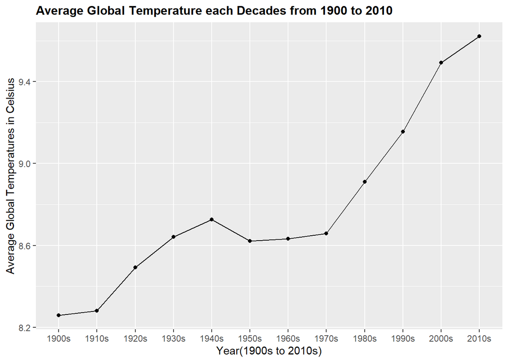

From the resulting line graph, we can clearly see an rising trend of global temperature, with slight decreases from 1940s to 1950s. There was a continuous and notable increase from 1970s to 2010s for about 1 degree Celsius. Although the increments from 2000s to 2010s in lower than the changes in former decades, it still proved that the global warming effect existed and was not controlled.

### Chart 3

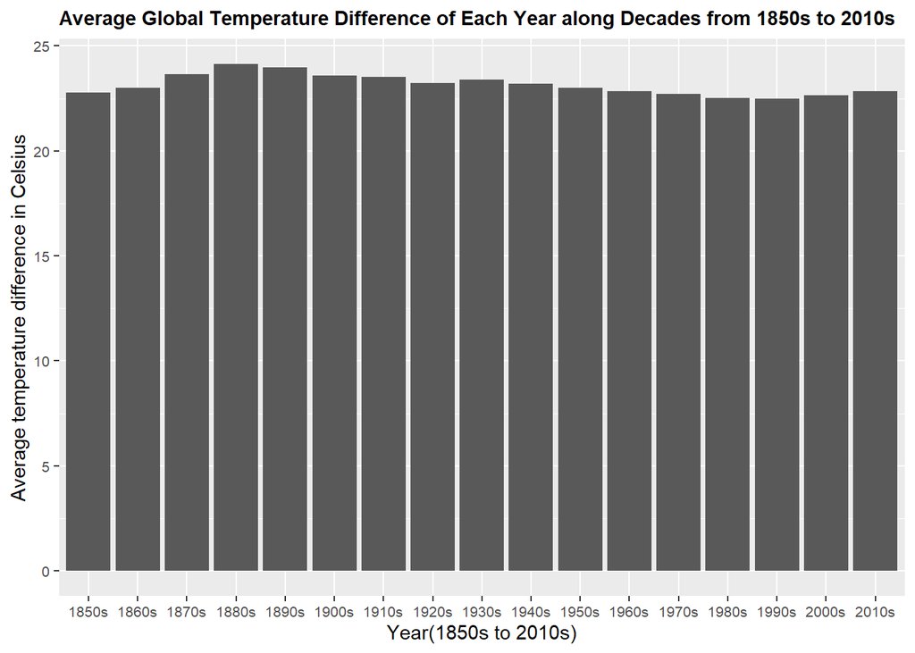

This chart is about the Average Global Temperature Difference of Each Year along Decades from 1850s to 2010s, which is generated by calculating each year’s maximum temperature difference and then take the average of each decades. The reason for us to include this chart is that we want to know what the temperature difference trend looks like throughout the history thus to interpret whether the climate is becoming worse or not. Surprisingly, the data is not gradually increase. Instead, there is a great peak in 1880s and a relatively small peak in 1930s. The possible reason for that is the second industrial revolution as well as the preparation for the WWII. Moreover, the temperature difference has begun rising since 1990s, which may due to the development of modern technology.